# Id0003_Trevino Assemble Adata

- Show All Code
- Hide All Code

*Notebook version R24.06.V6 for CellRanger tsv/txt files (read_csv)*

# Dataset Information

## References

- Paper
- [Dataset interactive Viewer](https://scbrainregulation.su.domains/)

## General info

- Samples: **human fetal brain cortex at mid-gestation** (4 subjects from PCW16 to PCW24)
- Sequencing method: single cell RNASequencing (Chromium platform - 10x Genomics)
- Obtained number of cells: **~58,000**

[figure not shown]

## Short description

> single cell atlas of gene expression of human developing cortex during mid-gestation.

## Metadata

Key metadata already made avaialble from the authors:

- Sample ID
- Tissue
- Post-conceptional week
- Cell clusters (seurat_cluster)
- Assay and Batch
- QC: several metrics

**Cell populations identified by the authors in seurat_cluster:**

Information retrieved from paper supplementary material (excel tables):

- **c0**: GluN5; Glutamatergic Neuron 5
- **c1**: CGE IN; CGE Interneuron
- **c2**: GluN1; Glutamatergic Neuron 1
- **c3**: MGE IN; MGE Interneuron
- **c4**: GluN4; Glutamatergic Neuron 4
- **c5**: GluN2; Glutamatergic Neuron 2
- **c6**: Early RG; Early Radial Glia
- **c7**: GluN7; Glutamatergic Neuron 7
- **c8**: Cyc. Prog.; Cycling Progenitor
- **c9**: GluN3; Glutamatergic Neuron 3
- **c10**: Late RG; Late Radial Glia
- **c11**: mGPC; Multipotent glial progenitor cell
- **c12**: GluN6; Glutamatergic Neuron 6
- **c13**: SP; Subplate
- **c14**: nIPC; neuronal intermedate progenitor cell
- **c15**: GluN8; Glutamatergic Neuron 8
- **c16**: MG; Microglia
- **c17**: OPC/Oligo; Oligodendrocyte Progenitor Cell/Oligodendrocyte
- **c18**: tRG; Truncated Radial Glia
- **c19**: Peric.; Pericyte
- **c20**: EC; Endothelial Cell
- **c21**: RBC; Red Blood Cell
- **c22**: VLMC; Vascular and Leptomeningeal Cell

[figure not shown]

# 1. Environment setup

## 1.1 Modules

```python
import os
import sys

import numpy as np
import pandas as pd
import anndata as ad
import scanpy as sc
from scipy.sparse import csr_matrix, isspmatrix

import matplotlib.pyplot as plt
import scanpy.external as sce

from datetime import datetime
import ipynbname

print("Scanpy version: ", sc.__version__)
print("Pandas version: ", pd.__version__)
```

```
Scanpy version:  1.10.1
Pandas version:  2.2.2
```

```python
# Custom functions
sys.path.append('../HelperFunctions')
import Helper as fn
```

## 1.2 Settings

```python
sc.settings.verbosity = 3
sc.settings.set_figure_params(dpi=120)
```

## 1.3 Files

```python
path = '../../DataDir/'
Id = 'Id0003'

input_file = path + Id + '/0_Starting/GSE162170_rna_counts.tsv'
meta_file = path + Id + '/0_Starting/GSE162170_rna_cell_metadata.txt'
output_file = path + Id + '/1_AssembledAdata.h5ad'
```

## 1.4 Start computations

```python
print(datetime.now())
```

```
2024-08-06 10:46:08.077188
```

# 2. Data Load

- Load raw counts
- Transpose adata to have barcodes as obs and genes as var
- Matrix from dense to sparse
- Read barcode metadata

## 2.1 Load raw count data

```python
adata = sc.read_csv(input_file, delimiter='\t', first_column_names=None, dtype='float32')
```

```python
if isspmatrix(adata.X) == False:
    adata.X = csr_matrix(adata.X)
    print('Converted adata.X to', type(adata.X))
```

```
Converted adata.X to <class 'scipy.sparse._csr.csr_matrix'>
```

```python
adata = adata.transpose()
adata
```

```
AnnData object with n_obs × n_vars = 57868 × 33355
```

## 2.2 Read Metadata

```python
meta = pd.read_csv(meta_file, sep = '\t', index_col='Cell.ID')
meta = meta.add_prefix('Auth_')
print(meta.shape)
meta.head()
```

```
(57868, 21)
```

| Cell.ID | Auth_Sample.ID | Auth_Age | Auth_Tissue.ID | Auth_Sample.Type | Auth_Assay | Auth_Batch | Auth_seurat_clusters | Auth_RNA.Counts | Auth_RNA.Features | Auth_Percent.MT | ... | Auth_Cell.Barcode | Auth_DF_pANN | Auth_DF_classification | Auth_DF_pANN_quantile | Auth_Spliced.Counts | Auth_Spliced.Features | Auth_Unspliced.Counts | Auth_Unspliced.Features | Auth_Ambiguous.Counts | Auth_Ambiguous.Features |
| --- | --- | --- | --- | --- | --- | --- | --- | --- | --- | --- | --- | --- | --- | --- | --- | --- | --- | --- | --- | --- | --- |
| hft_w20_p3_r1_AAACCCAAGCTGCGAA | hft_w20_p3_r1 | pcw20 | HFT3 | HFT | RNA v3 | b2019_06 | c16 | 1397 | 677 | 0.070866 | ... | AAACCCAAGCTGCGAA | 0.086339 | Singlet | 0.356997 | 1063 | 544 | 67 | 54 | 94 | 69 |
| hft_w20_p3_r1_AAACCCAAGGTAGTAT | hft_w20_p3_r1 | pcw20 | HFT3 | HFT | RNA v3 | b2019_06 | c11 | 14338 | 4301 | 0.053200 | ... | AAACCCAAGGTAGTAT | 0.325683 | Singlet | 0.821429 | 10339 | 3514 | 5437 | 2526 | 1431 | 669 |
| hft_w20_p3_r1_AAACCCACAACTCCAA | hft_w20_p3_r1 | pcw20 | HFT3 | HFT | RNA v3 | b2019_06 | c17 | 9260 | 3481 | 0.043511 | ... | AAACCCACAACTCCAA | 0.397814 | Doublet | 0.984402 | 6494 | 2701 | 6860 | 2515 | 1095 | 669 |
| hft_w20_p3_r1_AAACCCACATAGTCAC | hft_w20_p3_r1 | pcw20 | HFT3 | HFT | RNA v3 | b2019_06 | c0 | 4025 | 1969 | 0.015396 | ... | AAACCCACATAGTCAC | 0.076503 | Singlet | 0.314723 | 2655 | 1475 | 5875 | 2058 | 634 | 377 |
| hft_w20_p3_r1_AAACCCAGTACAGGTG | hft_w20_p3_r1 | pcw20 | HFT3 | HFT | RNA v3 | b2019_06 | c4 | 7131 | 2930 | 0.044690 | ... | AAACCCAGTACAGGTG | 0.239344 | Singlet | 0.746356 | 5008 | 2228 | 6026 | 2106 | 909 | 556 |

5 rows × 21 columns

# 3. Create adata object

- X slot: check integers, sparsity, maximum value, change format
- Add obs metadata
- For all steps: check coherence of raw counts and metadata size: if different, a ‘CAREFUL’ message is printed.

## 3.1 Adata X slot

```python
#check that adata.X contains integers
if adata.shape[0] <= 250000:
    print('Checking complete adata')
    if np.equal(np.mod(adata.X.toarray(), 1), 0).all() != True:
        print('CAREFUL: non-integer matrix loaded!')

if adata.shape[0] > 250000:
    print ('Checking a subsample of adata')
    if np.equal(np.mod(sc.pp.subsample(adata, n_obs=250000, random_state=0, copy=True).X.toarray(), 1), 0).all() != True:
        print('CAREFUL: non-integer matrix loaded!')
```

```
Checking complete adata
```

```python
print(adata.X[45:50, 45:50])
```

```
  (2, 1)    1.0
  (4, 2)    1.0
  (2, 4)    1.0
```

```python
maxCount = csr_matrix.max(adata.X)
print(maxCount)

if maxCount < 32000:
    print('Change X type to integer')
    adata.X = adata.X.astype('uint16')
else:
    print('X type not changed')
```

```
9222.0
Change X type to integer
```

```python
print(adata.X[45:50, 45:50])
print(csr_matrix.max(adata.X))

if (csr_matrix.max(adata.X)) != maxCount:
    print('CAREFUL: max count value has changed!')
```

```
  (2, 1)    1
  (4, 2)    1
  (2, 4)    1
9222
```

## 3.2 Obs slot

Add barcode annotation

```python
if meta.shape[0] != adata.obs.shape[0]:
    print('CAREFUL: expression matrix and metadata size are not coherent!')
    print ('Metadata rows: ' + str(meta.shape[0]))
```

```python
adata.obs = adata.obs.join(meta, how='left', validate='one_to_one')
del meta
```

```python
adata.obs.head(3)
```

|  | Auth_Sample.ID | Auth_Age | Auth_Tissue.ID | Auth_Sample.Type | Auth_Assay | Auth_Batch | Auth_seurat_clusters | Auth_RNA.Counts | Auth_RNA.Features | Auth_Percent.MT | ... | Auth_Cell.Barcode | Auth_DF_pANN | Auth_DF_classification | Auth_DF_pANN_quantile | Auth_Spliced.Counts | Auth_Spliced.Features | Auth_Unspliced.Counts | Auth_Unspliced.Features | Auth_Ambiguous.Counts | Auth_Ambiguous.Features |
| --- | --- | --- | --- | --- | --- | --- | --- | --- | --- | --- | --- | --- | --- | --- | --- | --- | --- | --- | --- | --- | --- |
| hft_w20_p3_r1_AAACCCAAGCTGCGAA | hft_w20_p3_r1 | pcw20 | HFT3 | HFT | RNA v3 | b2019_06 | c16 | 1397 | 677 | 0.070866 | ... | AAACCCAAGCTGCGAA | 0.086339 | Singlet | 0.356997 | 1063 | 544 | 67 | 54 | 94 | 69 |
| hft_w20_p3_r1_AAACCCAAGGTAGTAT | hft_w20_p3_r1 | pcw20 | HFT3 | HFT | RNA v3 | b2019_06 | c11 | 14338 | 4301 | 0.053200 | ... | AAACCCAAGGTAGTAT | 0.325683 | Singlet | 0.821429 | 10339 | 3514 | 5437 | 2526 | 1431 | 669 |
| hft_w20_p3_r1_AAACCCACAACTCCAA | hft_w20_p3_r1 | pcw20 | HFT3 | HFT | RNA v3 | b2019_06 | c17 | 9260 | 3481 | 0.043511 | ... | AAACCCACAACTCCAA | 0.397814 | Doublet | 0.984402 | 6494 | 2701 | 6860 | 2515 | 1095 | 669 |

3 rows × 21 columns

## 3.3 Var slot

Since var is expressed as Ensembl Gene Code, gene symbol has to be retrieved.

- Query biomart to retrieve gene annotation
- Add gene annotation to adata.var. Use Ensembl gene ID for genes with missing gene name
- Substitute gene name as index

```python
annot = sc.queries.biomart_annotations(
        "hsapiens",
        ["ensembl_gene_id", "external_gene_name","start_position", "end_position", "chromosome_name"],
    ).set_index("ensembl_gene_id")
```

```python
adata.var = adata.var.join(annot, how='left', validate='one_to_one')
print(adata.var['external_gene_name'].isnull().sum())
del annot
```

```
8399
```

```python
adata.var['ensg'] = adata.var.index.tolist()
adata.var['external_gene_name'] = adata.var['external_gene_name'].fillna(adata.var.ensg)
```

```python
#replace external gene name as index
adata.var.index = adata.var['external_gene_name']
adata.var.drop('external_gene_name', axis = 1, inplace = True)
adata.var_names_make_unique()
```

```python
adata.var.head(3)
```

| external_gene_name | start_position | end_position | chromosome_name | ensg |
| --- | --- | --- | --- | --- |
| MIR1302-2HG | 29554.0 | 31109.0 | 1 | ENSG00000243485 |
| FAM138A | 34554.0 | 36081.0 | 1 | ENSG00000237613 |
| OR4F5 | 65419.0 | 71585.0 | 1 | ENSG00000186092 |

## 3.4 Create necessary obs fields

I add obs fields that will be used in downstream computations:

- **dataset_id**
- **sample_id** from Sample ID
- **cell_label** from seurat_cluster. Using information from paper supplementary material, change labels.
- **brain_region**
- **age**
- **stage**: prenatal

```python
adata.obs['dataset_id'] = 'Id0003'
adata.obs['sample_id'] = adata.obs['Auth_Sample.ID']
adata.obs['brain_region'] = 'cerebral_cortex'
adata.obs['age'] = adata.obs['Auth_Age'].str.replace('pcw', 'PCW_')
adata.obs['stage'] = 'prenatal'
adata.obs['batch_key'] = adata.obs['Auth_Batch'] + '_' + adata.obs['Auth_Assay'].str.replace(' ', '')
```

```python
Dict = {'c0': 'ExN_N5', 'c1': 'In_CGE', 'c2': 'ExN_N1',
        'c3': 'In_MGE', 'c4': 'ExN_N4', 'c5': 'ExN_N2',
        'c6': 'RG_early', 'c7': 'ExN_N7', 'c8': 'CycProg',
        'c9': 'ExN_N3', 'c10': 'RG_late', 'c11': 'GliaPg',
        'c12': 'ExN_N6', 'c13': 'SubPlate', 'c14': 'IPC',
        'c15': 'ExN_N8', 'c16': 'Microglia', 'c17': 'OPC_Oligo',
        'c18': 'tRG', 'c19': 'Pericytes', 'c20': 'Endo',
        'c21': 'RBC', 'c22': 'VLMC'
       }

adata.obs['cell_label'] = adata.obs['Auth_seurat_clusters'].replace(Dict)
```

```python
adata.obs.head(3)
```

|  | Auth_Sample.ID | Auth_Age | Auth_Tissue.ID | Auth_Sample.Type | Auth_Assay | Auth_Batch | Auth_seurat_clusters | Auth_RNA.Counts | Auth_RNA.Features | Auth_Percent.MT | ... | Auth_Unspliced.Features | Auth_Ambiguous.Counts | Auth_Ambiguous.Features | dataset_id | sample_id | brain_region | age | stage | batch_key | cell_label |
| --- | --- | --- | --- | --- | --- | --- | --- | --- | --- | --- | --- | --- | --- | --- | --- | --- | --- | --- | --- | --- | --- |
| hft_w20_p3_r1_AAACCCAAGCTGCGAA | hft_w20_p3_r1 | pcw20 | HFT3 | HFT | RNA v3 | b2019_06 | c16 | 1397 | 677 | 0.070866 | ... | 54 | 94 | 69 | Id0003 | hft_w20_p3_r1 | cerebral_cortex | PCW_20 | prenatal | b2019_06_RNAv3 | Microglia |
| hft_w20_p3_r1_AAACCCAAGGTAGTAT | hft_w20_p3_r1 | pcw20 | HFT3 | HFT | RNA v3 | b2019_06 | c11 | 14338 | 4301 | 0.053200 | ... | 2526 | 1431 | 669 | Id0003 | hft_w20_p3_r1 | cerebral_cortex | PCW_20 | prenatal | b2019_06_RNAv3 | GliaPg |
| hft_w20_p3_r1_AAACCCACAACTCCAA | hft_w20_p3_r1 | pcw20 | HFT3 | HFT | RNA v3 | b2019_06 | c17 | 9260 | 3481 | 0.043511 | ... | 2515 | 1095 | 669 | Id0003 | hft_w20_p3_r1 | cerebral_cortex | PCW_20 | prenatal | b2019_06_RNAv3 | OPC_Oligo |

3 rows × 28 columns

# 4. Explore metadata

```python
print('Available metadata for each cell: ', adata.obs.columns)
```

```
Available metadata for each cell:  Index(['Auth_Sample.ID', 'Auth_Age', 'Auth_Tissue.ID', 'Auth_Sample.Type',
       'Auth_Assay', 'Auth_Batch', 'Auth_seurat_clusters', 'Auth_RNA.Counts',
       'Auth_RNA.Features', 'Auth_Percent.MT', 'Auth_Percent.Ribo',
       'Auth_Cell.Barcode', 'Auth_DF_pANN', 'Auth_DF_classification',
       'Auth_DF_pANN_quantile', 'Auth_Spliced.Counts', 'Auth_Spliced.Features',
       'Auth_Unspliced.Counts', 'Auth_Unspliced.Features',
       'Auth_Ambiguous.Counts', 'Auth_Ambiguous.Features', 'dataset_id',
       'sample_id', 'brain_region', 'age', 'stage', 'batch_key', 'cell_label'],
      dtype='object')
```

### Cell Label

```python
adata.obs['cell_label'].value_counts()
```

```
cell_label
ExN_N5       11367
In_CGE        5510
ExN_N1        4984
In_MGE        4337
ExN_N4        3954
ExN_N2        3784
RG_early      3155
ExN_N7        2703
CycProg       2701
ExN_N3        2685
RG_late       1969
GliaPg        1920
ExN_N6        1627
SubPlate      1333
IPC           1303
ExN_N8        1210
Microglia      944
OPC_Oligo      873
tRG            713
Pericytes      448
Endo           273
RBC             45
VLMC            30
Name: count, dtype: int64
```

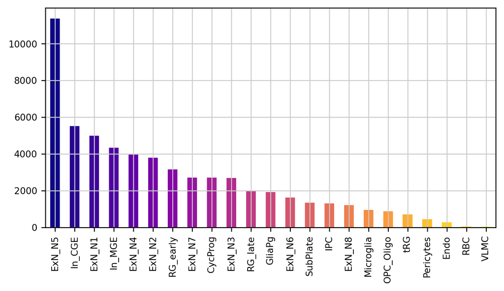

```python
plt.rcParams['figure.figsize'] = [7, 3.5]
fn.metaBarplot(adata, 'cell_label')
```

### Sample ID, Tissue, Age

```python
pd.crosstab(adata.obs['sample_id'], adata.obs['Auth_Tissue.ID'], dropna=False)
```

| Auth_Tissue.ID sample_id | HFT3 | HFT5 | HFT6 | HFT7 |
| --- | --- | --- | --- | --- |
| hft_w16_p7_r1 | 0 | 0 | 0 | 9294 |
| hft_w16_p7_r2 | 0 | 0 | 0 | 10079 |
| hft_w20_p3_r1 | 6393 | 0 | 0 | 0 |
| hft_w20_p3_r2 | 6174 | 0 | 0 | 0 |
| hft_w21_p5_r1 | 0 | 6169 | 0 | 0 |
| hft_w21_p5_r2 | 0 | 6388 | 0 | 0 |
| hft_w24_p6_r1 | 0 | 0 | 6131 | 0 |
| hft_w24_p6_r2 | 0 | 0 | 7240 | 0 |

```python
pd.crosstab(adata.obs['sample_id'], adata.obs['age'], dropna=False)
```

| age sample_id | PCW_16 | PCW_20 | PCW_21 | PCW_24 |
| --- | --- | --- | --- | --- |
| hft_w16_p7_r1 | 9294 | 0 | 0 | 0 |
| hft_w16_p7_r2 | 10079 | 0 | 0 | 0 |
| hft_w20_p3_r1 | 0 | 6393 | 0 | 0 |
| hft_w20_p3_r2 | 0 | 6174 | 0 | 0 |
| hft_w21_p5_r1 | 0 | 0 | 6169 | 0 |
| hft_w21_p5_r2 | 0 | 0 | 6388 | 0 |
| hft_w24_p6_r1 | 0 | 0 | 0 | 6131 |
| hft_w24_p6_r2 | 0 | 0 | 0 | 7240 |

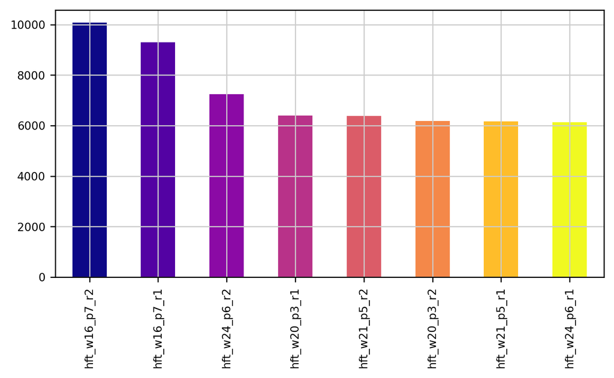

```python
fn.metaBarplot(adata, 'sample_id')
```

### Sample Type, Assay, Batch

```python
pd.crosstab(adata.obs['Auth_Sample.Type'], adata.obs['sample_id'], dropna=False)
```

| sample_id Auth_Sample.Type | hft_w16_p7_r1 | hft_w16_p7_r2 | hft_w20_p3_r1 | hft_w20_p3_r2 | hft_w21_p5_r1 | hft_w21_p5_r2 | hft_w24_p6_r1 | hft_w24_p6_r2 |
| --- | --- | --- | --- | --- | --- | --- | --- | --- |
| HFT | 9294 | 10079 | 6393 | 6174 | 6169 | 6388 | 6131 | 7240 |

```python
pd.crosstab(adata.obs['Auth_Assay'], adata.obs['sample_id'], dropna=False)
```

| sample_id Auth_Assay | hft_w16_p7_r1 | hft_w16_p7_r2 | hft_w20_p3_r1 | hft_w20_p3_r2 | hft_w21_p5_r1 | hft_w21_p5_r2 | hft_w24_p6_r1 | hft_w24_p6_r2 |
| --- | --- | --- | --- | --- | --- | --- | --- | --- |
| RNA NG | 9294 | 10079 | 0 | 0 | 0 | 0 | 6131 | 7240 |
| RNA v3 | 0 | 0 | 6393 | 6174 | 6169 | 6388 | 0 | 0 |

```python
pd.crosstab(adata.obs['Auth_Batch'], adata.obs['sample_id'], dropna=False)
```

| sample_id Auth_Batch | hft_w16_p7_r1 | hft_w16_p7_r2 | hft_w20_p3_r1 | hft_w20_p3_r2 | hft_w21_p5_r1 | hft_w21_p5_r2 | hft_w24_p6_r1 | hft_w24_p6_r2 |
| --- | --- | --- | --- | --- | --- | --- | --- | --- |
| b2019_06 | 0 | 0 | 6393 | 6174 | 0 | 0 | 0 | 0 |
| b2020_02 | 0 | 0 | 0 | 0 | 6169 | 6388 | 6131 | 7240 |
| b2020_03 | 9294 | 10079 | 0 | 0 | 0 | 0 | 0 | 0 |

```python
pd.crosstab(adata.obs['Auth_Batch'], adata.obs['Auth_Assay'], dropna=False)
```

| Auth_Assay Auth_Batch | RNA NG | RNA v3 |
| --- | --- | --- |
| b2019_06 | 0 | 12567 |
| b2020_02 | 13371 | 12557 |
| b2020_03 | 19373 | 0 |

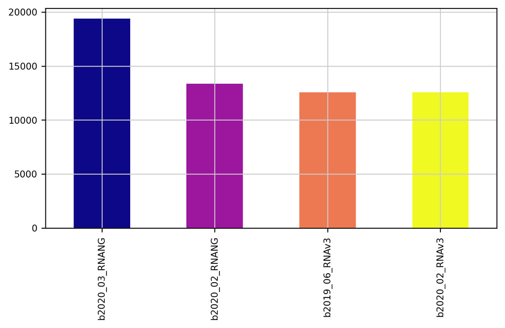

```python
fn.metaBarplot(adata, 'batch_key')
```

# 5. Saving

## 5.1 Save assembled adata

```python
adata
```

```
AnnData object with n_obs × n_vars = 57868 × 33355
    obs: 'Auth_Sample.ID', 'Auth_Age', 'Auth_Tissue.ID', 'Auth_Sample.Type', 'Auth_Assay', 'Auth_Batch', 'Auth_seurat_clusters', 'Auth_RNA.Counts', 'Auth_RNA.Features', 'Auth_Percent.MT', 'Auth_Percent.Ribo', 'Auth_Cell.Barcode', 'Auth_DF_pANN', 'Auth_DF_classification', 'Auth_DF_pANN_quantile', 'Au…
    var: 'start_position', 'end_position', 'chromosome_name', 'ensg'
```

```python
if isspmatrix(adata.X) == False:
    adata.X = csr_matrix(adata.X)
    print('Converted adata.X to', type(adata.X))
```

```python
adata.write(output_file, compression='gzip')
```

## 5.2 Finished computations

```python
print(datetime.now())
```

```
2024-08-06 10:50:36.424118
```